# Pesquisa Faculdade de Engenharia

Insper - Programa Avançado em Data Science - Marketing Analytics

Viviane Sanchez

10/23/2020 - 11/07/2020

# Introdução

## Objetivo

Avaliar o posicionamento da Faculdade de Engenharia do Insper a partir da pesquisa realizada.

## Pacotes

```r
library(tidyverse)
library(tidymodels)
library(tidytext)
library(skimr)
library(ggrepel)
library(factoextra)
library(zoo)
library(clue)
library(readxl)
library(janitor)
library(lubridate)
library(inspectdf)
library(knitr)

theme_set(theme_minimal())
theme_update(text = element_text(family = "Open Sans", size = 12),
             plot.title = element_text(face = "bold", size = 18,
                                       color = "#1d3752"),
             legend.position = "bottom")
```

# Dados

Para facilitar a manipulação dos dados, os tipos das variáveis presentes em cada coluna foram definidos conforme abaixo:

```r
types <- tibble(col_num = c(1:11),
               type = "guess") %>%
  bind_rows(tibble(col_num = c(12:102),
                   type = "text")) %>% pull(type)

insper_raw <- read_excel("data/Insper.xlsx", col_types = types)
```

## Pré-processamento

A seguir, dos nomes das colunas são extraídas as escolas e o tema de cada pergunta, assim como suas respostas. Combinando a função `pivot_longer` com expressões regulares (`regex`) o processo é aplicado de forma que a tabela de saída esteja no formato tidy. Como existem 3 pessoas na base que não deram resposta para nenhuma pergunta, essas linhas serão desconsideradas na análise.

```r
de_para <- tibble(melhor = c(1:8),
                  melhor_escola = c("fei","poli","maua","insper",
                              "usp_sc","mackenzie","ita","outra"))

escolas <- de_para %>% pull(melhor_escola)

insper <- insper_raw %>%
  filter(Finished != "0") %>%
  select(-Finished) %>%
  pivot_longer(cols = -c(1:11),
               names_to = c("pergunta", "escola"),
               names_pattern = '(\\w+|\\w+\\W|\\w+\\stecnico)(-\\w+)',
               values_to = "resposta") %>%
  clean_names() %>%
  rename_with(., ~ str_extract(.,"_[a-zA-Z]+\\z"), starts_with("x")) %>%
  rename_with(., ~ str_remove(.,"_"), starts_with("_")) %>%
  rename(outra_qual = qual,
         ref = cabeca) %>% #glimpse()
  left_join(de_para, by = "melhor") %>%
  mutate(melhor_escola = if_else(is.na(melhor_escola), "outra", melhor_escola),
         across(where(is.character), str_to_lower),
         idade = as.numeric(str_extract(idade, "\\d+")),
         resposta = if_else(resposta == "x", "0", resposta),
         resposta = if_else(is.na(resposta), 0, as.numeric(resposta)),
         pergunta = case_when(str_detect(pergunta, '_rio') ~ "infra",
                              str_detect(pergunta, 'rio') ~ "custo",
                              str_detect(pergunta, 'graduar') ~ "reconhecimento",
                              str_detect(pergunta, 'academico') ~ "rigor",
                              str_detect(pergunta, 'conhecimento') ~ "tecnica",
                              str_detect(pergunta, 'do tecnico') ~  "multidisciplinar",
                              TRUE ~ str_remove(pergunta, "\\W")),
         escola = str_remove(escola,"-"),
         escola = case_when(escola == "sao" ~ "usp",
                            is.na(escola) ~ "outra",
                            TRUE ~ escola),
        ref = case_when(str_detect(ref, 'poli|usp') ~ "poli",
                        str_detect(ref, 'outra') ~ outra_qual,
                        is.na(ref) ~ "outra",
                        str_detect(ref, 'insper') ~ "insper",
                        TRUE ~ ref)) %>% glimpse
```

```
## Rows: 5,850
## Columns: 15
## $ response_id   <chr> "r_t03dqaxsofan917", "r_t03dqaxsofan917", "r_t03dqaxsof…
## $ response_set  <chr> "default response set", "default response set", "defaul…
## $ name          <chr> "anonymous", "anonymous", "anonymous", "anonymous", "an…
## $ start_date    <dttm> 2015-04-27 13:35:00, 2015-04-27 13:35:00, 2015-04-27 1…
## $ end_date      <dttm> 2015-04-27 13:42:00, 2015-04-27 13:42:00, 2015-04-27 1…
## $ idade         <dbl> 18, 18, 18, 18, 18, 18, 18, 18, 18, 18, 18, 18, 18, 18,…
## $ curso         <dbl> 2, 2, 2, 2, 2, 2, 2, 2, 2, 2, 2, 2, 2, 2, 2, 2, 2, 2, 2…
## $ ref           <chr> "ita", "ita", "ita", "ita", "ita", "ita", "ita", "ita",…
## $ melhor        <dbl> 2, 2, 2, 2, 2, 2, 2, 2, 2, 2, 2, 2, 2, 2, 2, 2, 2, 2, 2…
## $ outra_qual    <chr> NA, NA, NA, NA, NA, NA, NA, NA, NA, NA, NA, NA, NA, NA,…
## $ fei           <chr> "6", "6", "6", "6", "6", "6", "6", "6", "6", "6", "6", …
## $ pergunta      <chr> "tradicional", "tradicional", "tradicional", "tradicion…
## $ escola        <chr> "poli", "maua", "insper", "usp", "mackenzie", "ita", "f…
## $ resposta      <dbl> 7, 7, 4, 5, 6, 7, 5, 4, 5, 7, 6, 5, 5, 6, 6, 6, 7, 7, 6…
## $ melhor_escola <chr> "poli", "poli", "poli", "poli", "poli", "poli", "poli",…
```

A seguir obtém-se a matriz necessária para a construção do mapa perceptual. É calculada a média aritmética de cada atributo (resposta) para cada escola.

```r
insper_prep <- insper %>%
  select(escola, pergunta, resposta) %>%
    group_by(escola, pergunta) %>%
    summarise(resposta = mean(resposta, na.rm = T))

insper_wide <- insper_prep  %>%
  pivot_wider(names_from = pergunta,
              values_from = resposta) %>%
  mutate(tradicional = if_else(is.na(tradicional), 0, tradicional)) %>%
  ungroup() %>%
  column_to_rownames(., var = "escola")

insper_wide %>%
  kable(digits = 2, align = "c")
```

|  | custo | empreendedorismo | infra | inovacao | interpessoal | multidisciplinar | networking | preferencia | reconhecimento | regrada | rigor | tecnica | tradicional |
| --- | --- | --- | --- | --- | --- | --- | --- | --- | --- | --- | --- | --- | --- |
| fei | 3.77 | 3.08 | 4.11 | 3.37 | 3.66 | 3.58 | 3.86 | 3.20 | 4.31 | 4.12 | 4.63 | 4.85 | 0.00 |
| insper | 5.00 | 6.69 | 6.78 | 6.78 | 6.55 | 7.12 | 6.17 | 5.72 | 5.34 | 3.43 | 6.28 | 4.82 | 1.85 |
| ita | 6.26 | 2.94 | 5.31 | 3.63 | 2.71 | 4.09 | 4.37 | 4.63 | 6.43 | 5.72 | 6.26 | 6.31 | 6.34 |
| mackenzie | 3.25 | 3.18 | 4.03 | 3.25 | 3.82 | 3.77 | 3.66 | 2.31 | 3.68 | 3.75 | 4.14 | 4.40 | 4.40 |
| maua | 3.80 | 3.38 | 4.48 | 3.72 | 3.95 | 3.85 | 4.15 | 3.11 | 4.38 | 4.25 | 4.83 | 4.91 | 4.82 |
| poli | 6.63 | 3.43 | 3.97 | 3.46 | 3.69 | 3.95 | 4.63 | 5.68 | 6.45 | 5.14 | 6.14 | 6.11 | 6.54 |
| usp | 6.08 | 3.37 | 4.17 | 3.46 | 3.83 | 4.32 | 4.43 | 4.15 | 5.51 | 4.55 | 5.48 | 5.45 | 5.57 |

```r
?kable
```

## PCA

Aplica-se então uma análise componentes principais.Observa-se que as 3 primeiras componentes explicam a variabilidade de 97,4% dos dados.

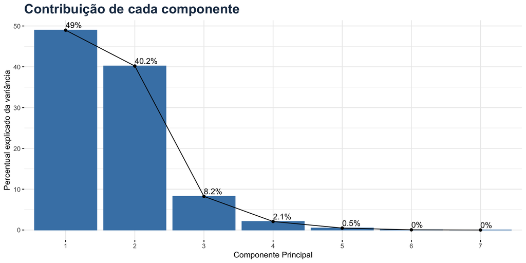

```r
insper_pca <- insper_wide %>%
  prcomp()

fviz_eig(insper_pca, addlabels = TRUE) +
  labs(x = "Componente Principal",
       y = "Percentual explicado da variância",
       title = "Contribuição de cada componente") +
  theme(plot.title = element_text(face = "bold", size = 18,
                                       color = "#1d3752"))
```

Ao olhar mais de perto a contribuição de cada atributo, pode-se dizer que as 3 primeiras componentes são drivers de *tradição*, *preferência* e *skills* respectivamente. Importante ressaltar que quando as contribuições são negativas, quanto maior o valor em módulo, mais distante a escola está daquele atributo.

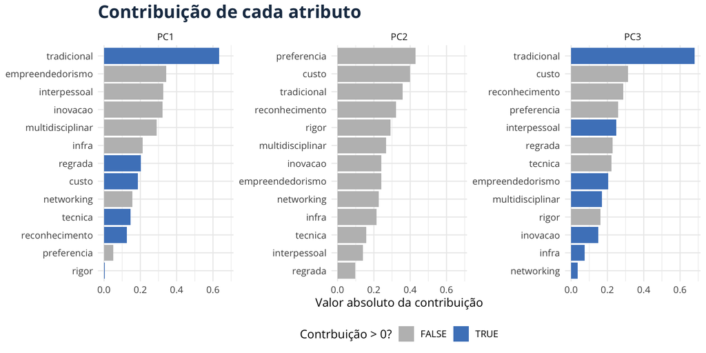

```r
as_tibble(insper_pca$rotation) %>%
  mutate(terms = rownames(insper_pca$rotation)) %>%
  pivot_longer(cols = PC1:PC7,
               names_to = "component",
               values_to = "value") %>%
  filter(component %in% paste0("PC", 1:3)) %>%
  mutate(terms = reorder_within(terms, abs(value), component)) %>%
  ggplot(aes(abs(value), terms, fill = value > 0)) +
  geom_col() +
  facet_wrap(~component, scales = "free_y") +
  scale_y_reordered() +
  scale_fill_manual(values = c("grey", "#4E84C4")) +
  labs(title = "Contribuição de cada atributo",
    x = "Valor absoluto da contribuição",
    y = NULL, fill = "Contrbuição > 0?")
```

Pelo mapa perceptual é possível consolidar todas as informações mostradas anteriormente:

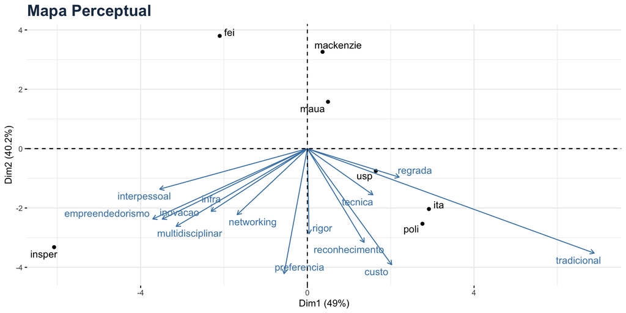

```r
fviz_pca_biplot(insper_pca, repel = T) +
  labs(title = "Mapa Perceptual") +
  theme(plot.title = element_text(face = "bold", size = 18,
                                       color = "#1d3752"))
```

Nota-se que o Insper está posicionado de forma isolada, na direção de habilidades como empreendedorismo, inovação, infraestrutura e networking. No entanto, está isolado, sem concorrentes diretos na percepção dos respondentes da pesquisa. ITA e POLI são vistas como as escolas mais tradicionais e com maior reconhecimento. Mauá, FEI e Mackenzie estão em sentidos opostos.

Outra forma de visualizar o território de cada faculdade é através do score médio nos principais drivers (Fernandez, et al.):

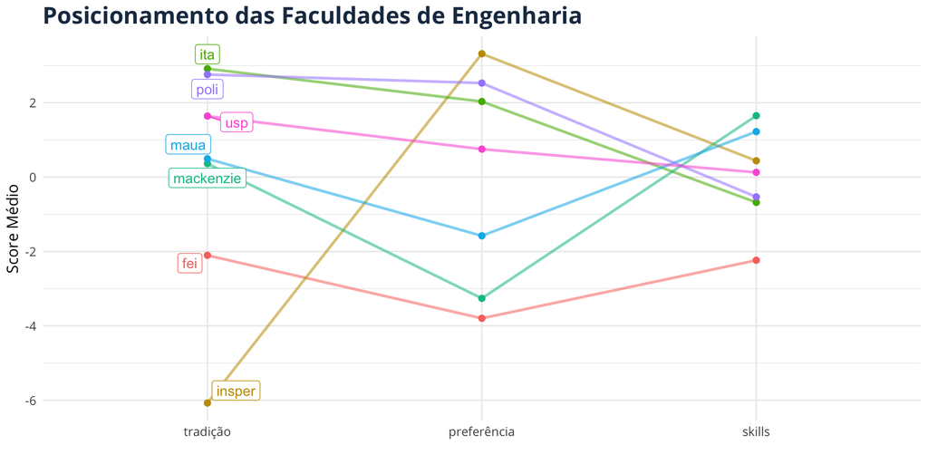

```r
z <- insper_pca$x[, 1:3]

tibble(escola = rownames(insper_wide)) %>%
        bind_cols(as_tibble(z)) %>%
  group_by(escola) %>%
  summarise_all(mean) %>%
  pivot_longer(cols = starts_with("PC"), names_to = "driver", values_to = "score_medio") %>%
  mutate(score_medio = if_else(driver == "PC2", -score_medio, score_medio)) %>%
  ggplot(aes(x = driver, y = score_medio, group = escola, color = escola,
             label = ifelse(driver == "PC1", escola, ""))) +
  geom_line(size = 1, alpha = 0.55) +
  geom_point(size = 2) +
  labs(x = "", y = "Score Médio", title = "Posicionamento das Faculdades de Engenharia") +
  geom_label_repel(direction = "both") +
  scale_x_discrete(labels = c("tradição", "preferência", "skills")) +
  theme(legend.position = "none")
```

ITA, Poli e USP São Carlos possuem os maiores socres em tradição, enquanto Mauá e Mackenzie se destacam no desenvolvimento de habilidades interpessoais (skills), o que não ficou claro pelo mapa, pois considera apenas os dois principais drivers. O Insper lidera a pesquisa no quesito preferência e é também reconhecido por essas habilidades.

# Conclusão

O mapa perceptual, criado a partir da análise de componentes principais, é uma ferramenta poderosa para avaliar o posicionamento de marcas a partir de uma pesquisa. Através da pesquisa conduzida, pode-se dizer que a faculdade de engenharia Insper se diferencia no mercado pelo desenvolvimento de habilidades interpessoais e é a preferida dentre os entrevistados.

# Referências

- Material de aula da matéria Marketing Analytics
- Material de aula da matéria Modelagem Preditiva Avançada
- University of Virginia - Wilcox, R. Methods for producing Perceptual Maps from Data
- Fernandez, P., et al, Data Science, Marketing e Business
- [PCA with penguins and recipes](https://allisonhorst.github.io/palmerpenguins/articles/articles/pca.html)